# 【第一回目 課題１】フレームワークを使わない深層学習

## (1): 全結合編

第1回目の課題１では，フレームワークを使わないで，pythonのnumpyのみを用いて簡単なネットワークの順伝搬，逆伝搬，学習を行ってみましょう．

まずは，全結合層＋ReLU＋2乗誤差関数 のネットワークを考えてみます．

全結合層を使って任意の関数の近似を行います．

```python
import math
import numpy as np
```

全結合層クラスFc を作ってみます． Fc(入力要素数，出力要素数) とします．

なお，numpyでは，１次元でベクトルを表現すると横ベクトル扱いになってしまうので， わかりやすくするために，ｎ次元ベクトルを(n,1)の２次元配列で表現することとして， 縦ベクトルで表現とします．

なお，Fcに活性化関数のReLUもまとめて入れてしまいます． さらに，update, updatem の勾配法によるパラメータの更新の メソッドも定義します．

```python
class Fc:
    def __init__(self, n_in, n_out, relu=True, seed=0):
        self.n_in=n_in
        self.n_out=n_out
        self.relu=relu
        # w,b は全結合層の学習パラメータ．
        # ReLuも全結合の中に含めてあります．
        # ReLU=Trueのときは，Heの初期値．Falseのときは，Xavierの初期値とします．．
        # xは直前のforward計算時の入力値．BPの計算時に必要．
        np.random.seed(seed) # 同じ初期値を再現できるように seed を指定します．
        if relu:
            self.w=np.random.normal(0, math.sqrt(2.0/n_in), (n_out, n_in)) # Heの初期値
            self.relu0=None # ReLUの順伝搬時に０以下で値が伝搬されない要素のインデックスを記録．BP時に利用．
        else:
            self.w=np.random.normal(0, math.sqrt(1.0/n_in), (n_out, n_in)) # Xavierの初期値
        self.b=np.zeros((n_out,1))
        self.x=np.zeros((n_in,1))
        #　誤差逆伝搬(Back-Propagation時の勾配を記録する変数)
        self.dEdx=np.zeros((n_in,1)) # dE/dx を表す　BPの時に直前レイヤに伝わる勾配でδと表現されます．
        self.dEdw=np.zeros((n_out,n_in)) # dE/dw を表す
        self.dEdb=np.zeros((n_out,1)) # dE/db を表す
        self.count=0
        # 以下，MomentamSDGのための設定
        self.mdw=np.zeros((n_out,n_in))
        self.mdb=np.zeros((n_out,1))

    # forward は __call__ を使って定義する．単純な 行列＊ベクトル＋ベクトル　の計算．
    def __call__(self,x):
        self.x = x
        self.y = np.dot(self.w, x) + self.b
        # ReLUは，値が０以下の要素は，０とする．０とした要素のインデックスは relu0に記録し，BP時に勾配を伝搬させない．
        if self.relu:
            self.relu0= self.y<=0
            self.y[self.relu0]=0
        return self.y

    # backward は，dE/dy を受け取って，dE/dx を出力．内部では，dE/dw, dE/db を更新
    def backward(self, dEdy):
          # 順伝搬時に値が０以下だった要素は勾配を０として，勾配伝搬しない．
          if self.relu:
              dEdy[self.relu0]=0
          dydx = np.transpose(self.w)  # dWx/dx= np.transpose(W) であることより．
          dydw = np.transpose(self.x)  # dWx/dW= np.transpose(x)
          # dydb = np.ones((self.n_out,1))   #  db/db = np.ones((n_out,1))　１なので特に計算しない．
          # dEdw, dEdb に勾配を加算．dEdx (δ)は前層へ伝搬する勾配で，backwardの返り値とする．
          self.dEdx = np.dot(dydx, dEdy)
          self.dEdw += np.dot(dEdy, dydw)
          self.dEdb += dEdy
          self.count +=1  # 勾配の平均を取るために，足した勾配のサンプル数を記録．
          return self.dEdx

    # 勾配をクリア
    def clear_grad(self):
        self.dEdw=0
        self.dEdb=0
        self.count=0

    # 勾配法で重みをアップデート．countで割って，足しこんだ勾配のサンプル数で平均を取る
    def update(self, lr=0.001):
        self.w -= self.dEdw/self.count * lr
        self.b -= self.dEdb/self.count * lr
        self.clear_grad()

    # 慣性項（モーメンタム項）付きの勾配法
    def updatem(self, lr=0.001, mu=0.9):
        self.mdw = mu*self.mdw - self.dEdw/self.count * lr
        self.mdb = mu*self.mdb - self.dEdb/self.count * lr
        self.w += self.mdw
        self.b += self.mdb
        self.clear_grad()
```

```python
model_param = 20

fc1=Fc(1, model_param)
fc2=Fc(model_param, model_param)
fc3=Fc(model_param, 1, False)
```

Fcクラスの定義が終わったので，次に，近似する関数の定義を行って，学習データ(training data)，検証データ(validation data)を生成します．

```python
def f(x):
    return 0.5*(x-2)**2-5

X_train=np.arange(-10,10,0.01,dtype=np.float32)
Y_train= f(X_train)

# X_train, Y_trainは１次元配列なので，reshapeで ２次元の(n,dim)に変換します．dim=1です．
X_train=np.reshape(X_train,[-1,1])   # (2000,)  -> (2000,1)
Y_train=np.reshape(Y_train,[-1,1])
num_train=np.size(X_train)

# テスト用の x も準備します．
X_val=np.arange(-8,8,0.1,dtype=np.float32)
Y_val= f(X_val)
X_val=np.reshape(X_val,[-1,1])
Y_val=np.reshape(Y_val,[-1,1])
num_val=np.size(X_val)
```

いよいよ，学習ループです． 誤差(loss)のグラフ表示も行います．

```python
%matplotlib inline
import matplotlib.pyplot as plt
from IPython import display

x0=np.reshape(X_val,[-1])

lr=0.001 #学習率
num_epoch=150 # エポック数
num_batch=100 # mini-batch サイズ
#plt.hold(False)
losses=np.array([])
losses_val=np.array([])
ep=np.array([])
# 表示エリアの設定
fig=plt.figure()
fig1 = fig.add_subplot(121)
fig2 = fig.add_subplot(122)
for epoch in range(num_epoch):
# Stochastic Gradient Descent なので，epochごとに学習データをシャッフルします．
    shuffler = np.random.permutation(num_train)
    X_train=X_train[shuffler]
    Y_train=Y_train[shuffler]
    for n in range(0, num_train, num_batch):
        loss=0
        for i in range(num_batch):
            # 順伝搬計算
            y=fc3(fc2(fc1(np.c_[X_train[n+i]])))
            # 誤差微分値，誤差値を計算します．
            dEdx=y-np.c_[Y_train[n+i]]
            loss+=(dEdx**2)*0.5
            # dEdx (δ)を計算して，逆伝搬します．
            dEdx=fc3.backward(dEdx)
            dEdx=fc2.backward(dEdx)
            dEdx=fc1.backward(dEdx)
        # minibatch の順伝搬，逆伝搬を行ったら，SDGで重みを更新
        fc1.update(lr)
        fc2.update(lr)
        fc3.update(lr)
        # 各epochの最初にグラフ表示を行います．
        if n==0:
            #print "[%d %d] loss: %f" % (epoch,n,loss/num_batch)
            losses=np.append(losses,loss/num_batch)
            ep=np.append(ep,epoch)
            # 検証用データの評価
            loss_val=0
            Y_pred=np.array([])
            for i in range(num_val):
                # 順伝搬計算
                y=fc3(fc2(fc1(np.c_[X_val[i]])))
                Y_pred=np.append(Y_pred,y)
                # 誤差微分値，誤差値
                dEdx=y-np.c_[Y_val[i]]
                loss_val+=(dEdx**2)*0.5
                # print y, Y_val[i], (dEdx**2)*0.5
            losses_val=np.append(losses_val, loss_val/num_val)
            display.clear_output(wait = True)
            fig1.axis([0, num_epoch, 0, 50])
            fig1.plot(ep,losses,"b")
            fig1.plot(ep,losses_val,"r")
            fig2.axis([-8,8,-10,30])
            y0=np.reshape(Y_pred,[-1])
            fig2.plot(x0,y0,"b")
            fig2.plot(x0,f(x0),"r")
            display.display(fig)
            if epoch<num_epoch-1:
                fig2.cla()

display.clear_output(wait = True)
```

```python
print("loss_val:",loss_val)
```

```
loss_val: [[579.46638899]]
```

### 課題1

以下の小問の(1)-(5)を解答し，さらに(6)-(9)を1つ以上選択し回答すること．

1. 上記のコードにおける全結合層の順伝搬，逆伝搬の計算方法を説明し，上記のコードを実行せよ．
2. Reluを３層ともFalseにした場合の結果はどうなるか？ 予想して実際に試してみよ．
3. モデルパラメータ（例えば，10->30) を変化させて，結果を比較せよ．(特に最終loss値)
4. 学習率を変化させて挙動を観察せよ．
5. モーメンタムSDGに変更して，ノーマルなSDGとの違いを観察せよ．モーメンタムSDGの実装は各自完成させよ．
6. 関数 $f(x)$ を自由に書き換え，実行せよ．
7. Adam, AdaGrad のどちらか一方，もしくは両方を実装して比較せよ．
8. 一定のepoch数，もしくは一定以下の誤差値で，学習率が段階的に下がるようし，効果を検証せよ．
9. 中間層の活性化関数にReLUに加えて，Sigmoidを追加し，(1)ReLu, (2)Sigmoid (3)活性化関数なし　の３通りを比較せよ．(なお，Sigmoidのbackward は $dEdy=dEdy*self.y*(1-self.y)$ で記述できる．)

### 1. 上記のコードにおける全結合層の順伝搬，逆伝搬の計算方法を説明し，上記のコードを実行せよ．

**全結合における順伝搬**

```
各ノードにおいて，入力側から出力側に（順方向に），入力xから，枝の重みwのドット積（内積）を掛けて，総和を取った後で，バイアスbを加算する．その後，全体に活性化関数を掛ける演算を行う．
```

**全結合における逆伝搬**

```
各ノードにおいて，出力側から入力側に（逆方向に），出力側から伝播してきた勾配に対して，当該ノードにおける重み行列の転置行列，または，入力の転置行列を掛ける演算を行う．
```

以下，上記コードをまとめて実行する．

```python
%matplotlib inline
import matplotlib.pyplot as plt
from IPython import display

x0=np.reshape(X_val,[-1])

lr=0.001 #学習率
num_epoch=150 # エポック数
num_batch=100 # mini-batch サイズ
#plt.hold(False)
losses=np.array([])
losses_val=np.array([])
ep=np.array([])
# 表示エリアの設定
fig=plt.figure()
fig1 = fig.add_subplot(121)
fig2 = fig.add_subplot(122)
for epoch in range(num_epoch):
# Stochastic Gradient Descent なので，epochごとに学習データをシャッフルします．
    shuffler = np.random.permutation(num_train)
    X_train=X_train[shuffler]
    Y_train=Y_train[shuffler]
    for n in range(0, num_train, num_batch):
        loss=0
        for i in range(num_batch):
            # 順伝搬計算
            y=fc3(fc2(fc1(np.c_[X_train[n+i]])))
            # 誤差微分値，誤差値を計算します．
            dEdx=y-np.c_[Y_train[n+i]]
            loss+=(dEdx**2)*0.5
            # dEdx (δ)を計算して，逆伝搬します．
            dEdx=fc3.backward(dEdx)
            dEdx=fc2.backward(dEdx)
            dEdx=fc1.backward(dEdx)
        # minibatch の順伝搬，逆伝搬を行ったら，SDGで重みを更新
        fc1.update(lr)
        fc2.update(lr)
        fc3.update(lr)
        # 各epochの最初にグラフ表示を行います．
        if n==0:
            #print "[%d %d] loss: %f" % (epoch,n,loss/num_batch)
            losses=np.append(losses,loss/num_batch)
            ep=np.append(ep,epoch)
            # 検証用データの評価
            loss_val=0
            Y_pred=np.array([])
            for i in range(num_val):
                # 順伝搬計算
                y=fc3(fc2(fc1(np.c_[X_val[i]])))
                Y_pred=np.append(Y_pred,y)
                # 誤差微分値，誤差値
                dEdx=y-np.c_[Y_val[i]]
                loss_val+=(dEdx**2)*0.5
                # print y, Y_val[i], (dEdx**2)*0.5
            losses_val=np.append(losses_val, loss_val/num_val)
            display.clear_output(wait = True)
            fig1.axis([0, num_epoch, 0, 50])
            fig1.plot(ep,losses,"b")
            fig1.plot(ep,losses_val,"r")
            fig2.axis([-8,8,-10,30])
            y0=np.reshape(Y_pred,[-1])
            fig2.plot(x0,y0,"b")
            fig2.plot(x0,f(x0),"r")
            display.display(fig)
            if epoch<num_epoch-1:
                fig2.cla()

display.clear_output(wait = True)
```

### 2. Reluを３層ともFalseにした場合の結果はどうなるか？ 予想して実際に試してみよ．

### 予想：

Reluを３層とも設定Falseにした場合は，いずれも初期値として，Xavierの初期値 $\sqrt{1/n}$ が選択される．これは，適切とされるHeの初期値 $\sqrt{2/n}$ よりも小さい値である．上記を踏まえると，数式自体はは大きく異ならないため，学習について大勢に影響はないものの，収束が遅れると予想する．

以下，実験を行う．

```
loss_val: [[10290.37360008]]
```

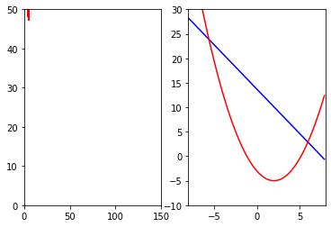

```python
%matplotlib inline
import matplotlib.pyplot as plt
from IPython import display

x0=np.reshape(X_val,[-1])

lr=0.001 #学習率
num_epoch=150 # エポック数
num_batch=100 # mini-batch サイズ
#plt.hold(False)
losses=np.array([])
losses_val=np.array([])
ep=np.array([])
# 表示エリアの設定
fig=plt.figure()
fig1 = fig.add_subplot(121)
fig2 = fig.add_subplot(122)

# Reluを3層ともFalseにする
fc1=Fc(1,20,False)
fc2=Fc(20,20,False)
fc3=Fc(20,1,False)

for epoch in range(num_epoch):
# Stochastic Gradient Descent なので，epochごとに学習データをシャッフルします．
    shuffler = np.random.permutation(num_train)
    X_train=X_train[shuffler]
    Y_train=Y_train[shuffler]
    for n in range(0, num_train, num_batch):
        loss=0
        for i in range(num_batch):
            # 順伝搬計算
            y=fc3(fc2(fc1(np.c_[X_train[n+i]])))
            # 誤差微分値，誤差値を計算します．
            dEdx=y-np.c_[Y_train[n+i]]
            loss+=(dEdx**2)*0.5
            # dEdx (δ)を計算して，逆伝搬します．
            dEdx=fc3.backward(dEdx)
            dEdx=fc2.backward(dEdx)
            dEdx=fc1.backward(dEdx)
        # minibatch の順伝搬，逆伝搬を行ったら，SDGで重みを更新
        fc1.update(lr)
        fc2.update(lr)
        fc3.update(lr)
        # 各epochの最初にグラフ表示を行います．
        if n==0:
            #print "[%d %d] loss: %f" % (epoch,n,loss/num_batch)
            losses=np.append(losses,loss/num_batch)
            ep=np.append(ep,epoch)
            # 検証用データの評価
            loss_val=0
            Y_pred=np.array([])
            for i in range(num_val):
                # 順伝搬計算
                y=fc3(fc2(fc1(np.c_[X_val[i]])))
                Y_pred=np.append(Y_pred,y)
                # 誤差微分値，誤差値
                dEdx=y-np.c_[Y_val[i]]
                loss_val+=(dEdx**2)*0.5
                # print y, Y_val[i], (dEdx**2)*0.5
            losses_val=np.append(losses_val, loss_val/num_val)
            display.clear_output(wait = True)
            fig1.axis([0, num_epoch, 0, 50])
            fig1.plot(ep,losses,"b")
            fig1.plot(ep,losses_val,"r")
            fig2.axis([-8,8,-10,30])
            y0=np.reshape(Y_pred,[-1])
            fig2.plot(x0,y0,"b")
            fig2.plot(x0,f(x0),"r")
            display.display(fig)
            if epoch<num_epoch-1:
                fig2.cla()

display.clear_output(wait = True)
print("loss_val:",loss_val)
```

### 結果

結果は予想（収束が遅れる）と大きく異なっており，学習が全く進まなかった．また，演算された損失の値は約10000であり，前の設問時の値（約580）と比較にならない程，大きい（良くない）値であった．

```python
# 適切な設定に戻す
# モデルパラメータの初期値２０に設定
model_param = 20
fc1=Fc(1, model_param)
fc2=Fc(model_param, model_param)
fc3=Fc(model_param, 1, False)
```

### 3. モデルパラメータ（例えば，10->30) を変化させて，結果を比較せよ．(特に最終loss値)

```
前々回のパラメータ値は model_param = 20 と設定した．
model_param = 10と設定する．
```

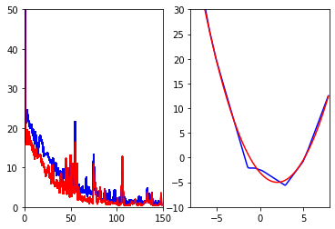

```python
%matplotlib inline
import matplotlib.pyplot as plt
from IPython import display

x0=np.reshape(X_val,[-1])

lr=0.001 #学習率
num_epoch=150 # エポック数
num_batch=100 # mini-batch サイズ
#plt.hold(False)
losses=np.array([])
losses_val=np.array([])
ep=np.array([])
# 表示エリアの設定
fig=plt.figure()
fig1 = fig.add_subplot(121)
fig2 = fig.add_subplot(122)

# モデルパラメータを１０に設定
model_param = 10
fc1=Fc(1, model_param)
fc2=Fc(model_param, model_param)
fc3=Fc(model_param, 1, False)

for epoch in range(num_epoch):
# Stochastic Gradient Descent なので，epochごとに学習データをシャッフルします．
    shuffler = np.random.permutation(num_train)
    X_train=X_train[shuffler]
    Y_train=Y_train[shuffler]
    for n in range(0, num_train, num_batch):
        loss=0
        for i in range(num_batch):
            # 順伝搬計算
            y=fc3(fc2(fc1(np.c_[X_train[n+i]])))
            # 誤差微分値，誤差値を計算します．
            dEdx=y-np.c_[Y_train[n+i]]
            loss+=(dEdx**2)*0.5
            # dEdx (δ)を計算して，逆伝搬します．
            dEdx=fc3.backward(dEdx)
            dEdx=fc2.backward(dEdx)
            dEdx=fc1.backward(dEdx)
        # minibatch の順伝搬，逆伝搬を行ったら，SDGで重みを更新
        fc1.update(lr)
        fc2.update(lr)
        fc3.update(lr)
        # 各epochの最初にグラフ表示を行います．
        if n==0:
            #print "[%d %d] loss: %f" % (epoch,n,loss/num_batch)
            losses=np.append(losses,loss/num_batch)
            ep=np.append(ep,epoch)
            # 検証用データの評価
            loss_val=0
            Y_pred=np.array([])
            for i in range(num_val):
                # 順伝搬計算
                y=fc3(fc2(fc1(np.c_[X_val[i]])))
                Y_pred=np.append(Y_pred,y)
                # 誤差微分値，誤差値
                dEdx=y-np.c_[Y_val[i]]
                loss_val+=(dEdx**2)*0.5
                # print y, Y_val[i], (dEdx**2)*0.5
            losses_val=np.append(losses_val, loss_val/num_val)
            display.clear_output(wait = True)
            fig1.axis([0, num_epoch, 0, 50])
            fig1.plot(ep,losses,"b")
            fig1.plot(ep,losses_val,"r")
            fig2.axis([-8,8,-10,30])
            y0=np.reshape(Y_pred,[-1])
            fig2.plot(x0,y0,"b")
            fig2.plot(x0,f(x0),"r")
            display.display(fig)
            if epoch<num_epoch-1:
                fig2.cla()

display.clear_output(wait = True)
```

```python
print("loss_val:",loss_val)
```

```
loss_val: [[55.59745607]]
```

```
model_param=30 と設定する．
```

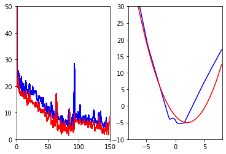

```python
%matplotlib inline
import matplotlib.pyplot as plt
from IPython import display

x0=np.reshape(X_val,[-1])

lr=0.001 #学習率
num_epoch=150 # エポック数
num_batch=100 # mini-batch サイズ
#plt.hold(False)
losses=np.array([])
losses_val=np.array([])
ep=np.array([])
# 表示エリアの設定
fig=plt.figure()
fig1 = fig.add_subplot(121)
fig2 = fig.add_subplot(122)

# モデルパラメータを３０に設定
model_param = 30
fc1=Fc(1, model_param)
fc2=Fc(model_param, model_param)
fc3=Fc(model_param, 1, False)

for epoch in range(num_epoch):
# Stochastic Gradient Descent なので，epochごとに学習データをシャッフルします．
    shuffler = np.random.permutation(num_train)
    X_train=X_train[shuffler]
    Y_train=Y_train[shuffler]
    for n in range(0, num_train, num_batch):
        loss=0
        for i in range(num_batch):
            # 順伝搬計算
            y=fc3(fc2(fc1(np.c_[X_train[n+i]])))
            # 誤差微分値，誤差値を計算します．
            dEdx=y-np.c_[Y_train[n+i]]
            loss+=(dEdx**2)*0.5
            # dEdx (δ)を計算して，逆伝搬します．
            dEdx=fc3.backward(dEdx)
            dEdx=fc2.backward(dEdx)
            dEdx=fc1.backward(dEdx)
        # minibatch の順伝搬，逆伝搬を行ったら，SDGで重みを更新
        fc1.update(lr)
        fc2.update(lr)
        fc3.update(lr)
        # 各epochの最初にグラフ表示を行います．
        if n==0:
            #print "[%d %d] loss: %f" % (epoch,n,loss/num_batch)
            losses=np.append(losses,loss/num_batch)
            ep=np.append(ep,epoch)
            # 検証用データの評価
            loss_val=0
            Y_pred=np.array([])
            for i in range(num_val):
                # 順伝搬計算
                y=fc3(fc2(fc1(np.c_[X_val[i]])))
                Y_pred=np.append(Y_pred,y)
                # 誤差微分値，誤差値
                dEdx=y-np.c_[Y_val[i]]
                loss_val+=(dEdx**2)*0.5
                # print y, Y_val[i], (dEdx**2)*0.5
            losses_val=np.append(losses_val, loss_val/num_val)
            display.clear_output(wait = True)
            fig1.axis([0, num_epoch, 0, 50])
            fig1.plot(ep,losses,"b")
            fig1.plot(ep,losses_val,"r")
            fig2.axis([-8,8,-10,30])
            y0=np.reshape(Y_pred,[-1])
            fig2.plot(x0,y0,"b")
            fig2.plot(x0,f(x0),"r")
            display.display(fig)
            if epoch<num_epoch-1:
                fig2.cla()

display.clear_output(wait = True)
```

```python
print("loss_val:",loss_val)
```

```
loss_val: [[1352.18964823]]
```

モデルパラメータ数と損失の値は次のようになった．

| model_param | 10 | 20 | 30 |
| --- | --- | --- | --- |
| loss_val | 55.59 | 579.46 | 1352.18 |

モデルパラメータ数（今回の場合はノード数）が１０の場合が，最も損失が小さかった．

今回は二次関数という，比較的単純なモデルであったために，ノード数を増加させる（一般的に，損失低減の効果がある）効果が，得られなかったものと考えた．

## 4. 学習率を変化させて挙動を観察せよ．

最も損失の小さい，モデルパラメータを１０に設定にした上で，次の実験を行う．

学習率 $lr$ の設定を変更する．まず，初期値は　$lr=0.001$　とする．

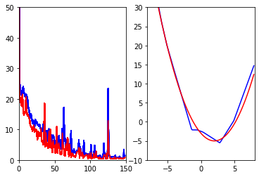

```python
%matplotlib inline
import matplotlib.pyplot as plt
from IPython import display

x0=np.reshape(X_val,[-1])

lr=0.001 #学習率
num_epoch=150 # エポック数
num_batch=100 # mini-batch サイズ
#plt.hold(False)
losses=np.array([])
losses_val=np.array([])
ep=np.array([])
# 表示エリアの設定
fig=plt.figure()
fig1 = fig.add_subplot(121)
fig2 = fig.add_subplot(122)

# モデルパラメータを１０に設定
model_param = 10
fc1=Fc(1, model_param)
fc2=Fc(model_param, model_param)
fc3=Fc(model_param, 1, False)

for epoch in range(num_epoch):
# Stochastic Gradient Descent なので，epochごとに学習データをシャッフルします．
    shuffler = np.random.permutation(num_train)
    X_train=X_train[shuffler]
    Y_train=Y_train[shuffler]
    for n in range(0, num_train, num_batch):
        loss=0
        for i in range(num_batch):
            # 順伝搬計算
            y=fc3(fc2(fc1(np.c_[X_train[n+i]])))
            # 誤差微分値，誤差値を計算します．
            dEdx=y-np.c_[Y_train[n+i]]
            loss+=(dEdx**2)*0.5
            # dEdx (δ)を計算して，逆伝搬します．
            dEdx=fc3.backward(dEdx)
            dEdx=fc2.backward(dEdx)
            dEdx=fc1.backward(dEdx)
        # minibatch の順伝搬，逆伝搬を行ったら，SDGで重みを更新
        fc1.update(lr)
        fc2.update(lr)
        fc3.update(lr)
        # 各epochの最初にグラフ表示を行います．
        if n==0:
            #print "[%d %d] loss: %f" % (epoch,n,loss/num_batch)
            losses=np.append(losses,loss/num_batch)
            ep=np.append(ep,epoch)
            # 検証用データの評価
            loss_val=0
            Y_pred=np.array([])
            for i in range(num_val):
                # 順伝搬計算
                y=fc3(fc2(fc1(np.c_[X_val[i]])))
                Y_pred=np.append(Y_pred,y)
                # 誤差微分値，誤差値
                dEdx=y-np.c_[Y_val[i]]
                loss_val+=(dEdx**2)*0.5
                # print y, Y_val[i], (dEdx**2)*0.5
            losses_val=np.append(losses_val, loss_val/num_val)
            display.clear_output(wait = True)
            fig1.axis([0, num_epoch, 0, 50])
            fig1.plot(ep,losses,"b")
            fig1.plot(ep,losses_val,"r")
            fig2.axis([-8,8,-10,30])
            y0=np.reshape(Y_pred,[-1])
            fig2.plot(x0,y0,"b")
            fig2.plot(x0,f(x0),"r")
            display.display(fig)
            if epoch<num_epoch-1:
                fig2.cla()

display.clear_output(wait = True)
```

```python
print("loss_val:",loss_val)
```

```
loss_val: [[142.86374968]]
```

### 学習率を， $lr=0.001$ から $0.01$ （初期値の１０倍）に変化させる．

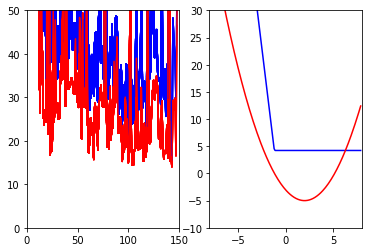

```python
%matplotlib inline
import matplotlib.pyplot as plt
from IPython import display

x0=np.reshape(X_val,[-1])

lr=0.01 #学習率
num_epoch=150 # エポック数
num_batch=100 # mini-batch サイズ
#plt.hold(False)
losses=np.array([])
losses_val=np.array([])
ep=np.array([])
# 表示エリアの設定
fig=plt.figure()
fig1 = fig.add_subplot(121)
fig2 = fig.add_subplot(122)

# モデルパラメータを１０に設定
model_param = 10
fc1=Fc(1, model_param)
fc2=Fc(model_param, model_param)
fc3=Fc(model_param, 1, False)

for epoch in range(num_epoch):
# Stochastic Gradient Descent なので，epochごとに学習データをシャッフルします．
    shuffler = np.random.permutation(num_train)
    X_train=X_train[shuffler]
    Y_train=Y_train[shuffler]
    for n in range(0, num_train, num_batch):
        loss=0
        for i in range(num_batch):
            # 順伝搬計算
            y=fc3(fc2(fc1(np.c_[X_train[n+i]])))
            # 誤差微分値，誤差値を計算します．
            dEdx=y-np.c_[Y_train[n+i]]
            loss+=(dEdx**2)*0.5
            # dEdx (δ)を計算して，逆伝搬します．
            dEdx=fc3.backward(dEdx)
            dEdx=fc2.backward(dEdx)
            dEdx=fc1.backward(dEdx)
        # minibatch の順伝搬，逆伝搬を行ったら，SDGで重みを更新
        fc1.update(lr)
        fc2.update(lr)
        fc3.update(lr)
        # 各epochの最初にグラフ表示を行います．
        if n==0:
            #print "[%d %d] loss: %f" % (epoch,n,loss/num_batch)
            losses=np.append(losses,loss/num_batch)
            ep=np.append(ep,epoch)
            # 検証用データの評価
            loss_val=0
            Y_pred=np.array([])
            for i in range(num_val):
                # 順伝搬計算
                y=fc3(fc2(fc1(np.c_[X_val[i]])))
                Y_pred=np.append(Y_pred,y)
                # 誤差微分値，誤差値
                dEdx=y-np.c_[Y_val[i]]
                loss_val+=(dEdx**2)*0.5
                # print y, Y_val[i], (dEdx**2)*0.5
            losses_val=np.append(losses_val, loss_val/num_val)
            display.clear_output(wait = True)
            fig1.axis([0, num_epoch, 0, 50])
            fig1.plot(ep,losses,"b")
            fig1.plot(ep,losses_val,"r")
            fig2.axis([-8,8,-10,30])
            y0=np.reshape(Y_pred,[-1])
            fig2.plot(x0,y0,"b")
            fig2.plot(x0,f(x0),"r")
            display.display(fig)
            if epoch<num_epoch-1:
                fig2.cla()

display.clear_output(wait = True)
```

```python
print("loss_val:",loss_val)
```

```
loss_val: [[21691.85810086]]
```

### また，学習率を， $lr=0.001$ から $0.0001$ （初期値の0.1倍）に変化させる．

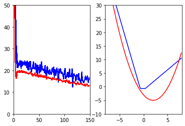

```python
%matplotlib inline
import matplotlib.pyplot as plt
from IPython import display

x0=np.reshape(X_val,[-1])

lr=0.0001 #学習率
num_epoch=150 # エポック数
num_batch=100 # mini-batch サイズ
#plt.hold(False)
losses=np.array([])
losses_val=np.array([])
ep=np.array([])
# 表示エリアの設定
fig=plt.figure()
fig1 = fig.add_subplot(121)
fig2 = fig.add_subplot(122)

# モデルパラメータを１０に設定
model_param = 10
fc1=Fc(1, model_param)
fc2=Fc(model_param, model_param)
fc3=Fc(model_param, 1, False)

for epoch in range(num_epoch):
# Stochastic Gradient Descent なので，epochごとに学習データをシャッフルします．
    shuffler = np.random.permutation(num_train)
    X_train=X_train[shuffler]
    Y_train=Y_train[shuffler]
    for n in range(0, num_train, num_batch):
        loss=0
        for i in range(num_batch):
            # 順伝搬計算
            y=fc3(fc2(fc1(np.c_[X_train[n+i]])))
            # 誤差微分値，誤差値を計算します．
            dEdx=y-np.c_[Y_train[n+i]]
            loss+=(dEdx**2)*0.5
            # dEdx (δ)を計算して，逆伝搬します．
            dEdx=fc3.backward(dEdx)
            dEdx=fc2.backward(dEdx)
            dEdx=fc1.backward(dEdx)
        # minibatch の順伝搬，逆伝搬を行ったら，SDGで重みを更新
        fc1.update(lr)
        fc2.update(lr)
        fc3.update(lr)
        # 各epochの最初にグラフ表示を行います．
        if n==0:
            #print "[%d %d] loss: %f" % (epoch,n,loss/num_batch)
            losses=np.append(losses,loss/num_batch)
            ep=np.append(ep,epoch)
            # 検証用データの評価
            loss_val=0
            Y_pred=np.array([])
            for i in range(num_val):
                # 順伝搬計算
                y=fc3(fc2(fc1(np.c_[X_val[i]])))
                Y_pred=np.append(Y_pred,y)
                # 誤差微分値，誤差値
                dEdx=y-np.c_[Y_val[i]]
                loss_val+=(dEdx**2)*0.5
                # print y, Y_val[i], (dEdx**2)*0.5
            losses_val=np.append(losses_val, loss_val/num_val)
            display.clear_output(wait = True)
            fig1.axis([0, num_epoch, 0, 50])
            fig1.plot(ep,losses,"b")
            fig1.plot(ep,losses_val,"r")
            fig2.axis([-8,8,-10,30])
            y0=np.reshape(Y_pred,[-1])
            fig2.plot(x0,y0,"b")
            fig2.plot(x0,f(x0),"r")
            display.display(fig)
            if epoch<num_epoch-1:
                fig2.cla()

display.clear_output(wait = True)
```

```python
print("loss_val:",loss_val)
```

```
loss_val: [[2080.10162987]]
```

学習率と損失の値は次のようになった．

[output not shown]

学習率が0.001の場合が，最も損失が小さかった．

グラフの概形から，学習率が大きすぎる場合は，学習が全く収束せず，学習率が小さすぎる場合は，学習が進まず，局所解に嵌っていると考えられる．

## 5. モーメンタムSGDに変更して，ノーマルなSGDとの違いを観察せよ．モーメンタムSGDの実装は各自完成させよ．

### ノーマルなSGDについて(fc.updateを利用)

```python
%matplotlib inline
import matplotlib.pyplot as plt
from IPython import display

x0=np.reshape(X_val,[-1])

lr=0.001 #学習率
num_epoch=150 # エポック数
num_batch=100 # mini-batch サイズ
#plt.hold(False)
losses=np.array([])
losses_val=np.array([])
ep=np.array([])
# 表示エリアの設定
fig=plt.figure()
fig1 = fig.add_subplot(121)
fig2 = fig.add_subplot(122)
for epoch in range(num_epoch):
# Stochastic Gradient Descent なので，epochごとに学習データをシャッフルします．
    shuffler = np.random.permutation(num_train)
    X_train=X_train[shuffler]
    Y_train=Y_train[shuffler]
    for n in range(0, num_train, num_batch):
        loss=0
        for i in range(num_batch):
            # 順伝搬計算
            y=fc3(fc2(fc1(np.c_[X_train[n+i]])))
            # 誤差微分値，誤差値を計算します．
            dEdx=y-np.c_[Y_train[n+i]]
            loss+=(dEdx**2)*0.5
            # dEdx (δ)を計算して，逆伝搬します．
            dEdx=fc3.backward(dEdx)
            dEdx=fc2.backward(dEdx)
            dEdx=fc1.backward(dEdx)
        # minibatch の順伝搬，逆伝搬を行ったら，SDGで重みを更新
        # updateがSGDで，updatemがモーメンタムSGD
        fc1.update(lr)
        fc2.update(lr)
        fc3.update(lr)
        # 各epochの最初にグラフ表示を行います．
        if n==0:
            #print "[%d %d] loss: %f" % (epoch,n,loss/num_batch)
            losses=np.append(losses,loss/num_batch)
            ep=np.append(ep,epoch)
            # 検証用データの評価
            loss_val=0
            Y_pred=np.array([])
            for i in range(num_val):
                # 順伝搬計算
                y=fc3(fc2(fc1(np.c_[X_val[i]])))
                Y_pred=np.append(Y_pred,y)
                # 誤差微分値，誤差値
                dEdx=y-np.c_[Y_val[i]]
                loss_val+=(dEdx**2)*0.5
                # print y, Y_val[i], (dEdx**2)*0.5
            losses_val=np.append(losses_val, loss_val/num_val)
            display.clear_output(wait = True)
            fig1.axis([0, num_epoch, 0, 50])
            fig1.plot(ep,losses,"b")
            fig1.plot(ep,losses_val,"r")
            fig2.axis([-8,8,-10,30])
            y0=np.reshape(Y_pred,[-1])
            fig2.plot(x0,y0,"b")
            fig2.plot(x0,f(x0),"r")
            display.display(fig)
            if epoch<num_epoch-1:
                fig2.cla()

display.clear_output(wait = True)
```

```python
print("loss_val:",loss_val)
```

[output not shown]

### モーメンタムSGDについて(fc.updatemを利用)

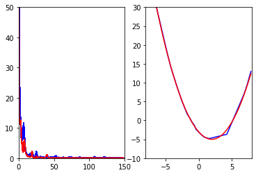

```python
%matplotlib inline
import matplotlib.pyplot as plt
from IPython import display

x0=np.reshape(X_val,[-1])

lr=0.001 #学習率
num_epoch=150 # エポック数
num_batch=100 # mini-batch サイズ
#plt.hold(False)
losses=np.array([])
losses_val=np.array([])
ep=np.array([])
# 表示エリアの設定
fig=plt.figure()
fig1 = fig.add_subplot(121)
fig2 = fig.add_subplot(122)
for epoch in range(num_epoch):
# Stochastic Gradient Descent なので，epochごとに学習データをシャッフルします．
    shuffler = np.random.permutation(num_train)
    X_train=X_train[shuffler]
    Y_train=Y_train[shuffler]
    for n in range(0, num_train, num_batch):
        loss=0
        for i in range(num_batch):
            # 順伝搬計算
            y=fc3(fc2(fc1(np.c_[X_train[n+i]])))
            # 誤差微分値，誤差値を計算します．
            dEdx=y-np.c_[Y_train[n+i]]
            loss+=(dEdx**2)*0.5
            # dEdx (δ)を計算して，逆伝搬します．
            dEdx=fc3.backward(dEdx)
            dEdx=fc2.backward(dEdx)
            dEdx=fc1.backward(dEdx)
        # minibatch の順伝搬，逆伝搬を行ったら，SDGで重みを更新
        # updateがSGDで，updatemがモーメンタムsgd
        fc1.updatem(lr)
        fc2.updatem(lr)
        fc3.updatem(lr)
        # 各epochの最初にグラフ表示を行います．
        if n==0:
            #print "[%d %d] loss: %f" % (epoch,n,loss/num_batch)
            losses=np.append(losses,loss/num_batch)
            ep=np.append(ep,epoch)
            # 検証用データの評価
            loss_val=0
            Y_pred=np.array([])
            for i in range(num_val):
                # 順伝搬計算
                y=fc3(fc2(fc1(np.c_[X_val[i]])))
                Y_pred=np.append(Y_pred,y)
                # 誤差微分値，誤差値
                dEdx=y-np.c_[Y_val[i]]
                loss_val+=(dEdx**2)*0.5
                # print y, Y_val[i], (dEdx**2)*0.5
            losses_val=np.append(losses_val, loss_val/num_val)
            display.clear_output(wait = True)
            fig1.axis([0, num_epoch, 0, 50])
            fig1.plot(ep,losses,"b")
            fig1.plot(ep,losses_val,"r")
            fig2.axis([-8,8,-10,30])
            y0=np.reshape(Y_pred,[-1])
            fig2.plot(x0,y0,"b")
            fig2.plot(x0,f(x0),"r")
            display.display(fig)
            if epoch<num_epoch-1:
                fig2.cla()

display.clear_output(wait = True)
```

```python
print("loss_val:",loss_val)
```

```
loss_val: [[8.62055777]]
```

### 観察

ノーマルSGDと比較して，モーメンタムSGDは，ジグザグの挙動が低減されているように見えた．過去の勾配（モーメンタム）の名の通り，ノーマルSGDより効率の良い学習が出来ていると推察される．

## 大問6.を選択して回答する．

## 6. 関数 $f(x)$ を自由に書き換え，実行せよ．

$f(x)=-ax^2+b$の２次式を確認すべく，$f(x) = -x^2+25 = -(x+5)(x-5)$ について検討する．

```python
def f(x):
    return -x**2+25

X_train=np.arange(-10,10,0.01,dtype=np.float32)
Y_train= f(X_train)

# X_train, Y_trainは１次元配列なので，reshapeで ２次元の(n,dim)に変換します．dim=1です．
X_train=np.reshape(X_train,[-1,1])   # (2000,)  -> (2000,1)
Y_train=np.reshape(Y_train,[-1,1])
num_train=np.size(X_train)

# テスト用の x も準備します．
X_val=np.arange(-8,8,0.1,dtype=np.float32)
Y_val= f(X_val)
X_val=np.reshape(X_val,[-1,1])
Y_val=np.reshape(Y_val,[-1,1])
num_val=np.size(X_val)
```

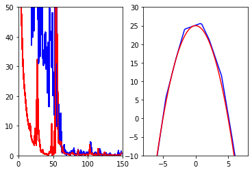

```python
%matplotlib inline
import matplotlib.pyplot as plt
from IPython import display

x0=np.reshape(X_val,[-1])

lr=0.001 #学習率
num_epoch=150 # エポック数
num_batch=100 # mini-batch サイズ
#plt.hold(False)
losses=np.array([])
losses_val=np.array([])
ep=np.array([])
# 表示エリアの設定
fig=plt.figure()
fig1 = fig.add_subplot(121)
fig2 = fig.add_subplot(122)

# モデルパラメータを最も良い10とする
model_param = 10
fc1=Fc(1, model_param)
fc2=Fc(model_param, model_param)
fc3=Fc(model_param, 1, False)

for epoch in range(num_epoch):
# Stochastic Gradient Descent なので，epochごとに学習データをシャッフルします．
    shuffler = np.random.permutation(num_train)
    X_train=X_train[shuffler]
    Y_train=Y_train[shuffler]
    for n in range(0, num_train, num_batch):
        loss=0
        for i in range(num_batch):
            # 順伝搬計算
            y=fc3(fc2(fc1(np.c_[X_train[n+i]])))
            # 誤差微分値，誤差値を計算します．
            dEdx=y-np.c_[Y_train[n+i]]
            loss+=(dEdx**2)*0.5
            # dEdx (δ)を計算して，逆伝搬します．
            dEdx=fc3.backward(dEdx)
            dEdx=fc2.backward(dEdx)
            dEdx=fc1.backward(dEdx)
        # minibatch の順伝搬，逆伝搬を行ったら，SGDで重みを更新
        # 特性の良いモーメンタムSGDを用いる．
        fc1.updatem(lr)
        fc2.updatem(lr)
        fc3.updatem(lr)
        # 各epochの最初にグラフ表示を行います．
        if n==0:
            #print "[%d %d] loss: %f" % (epoch,n,loss/num_batch)
            losses=np.append(losses,loss/num_batch)
            ep=np.append(ep,epoch)
            # 検証用データの評価
            loss_val=0
            Y_pred=np.array([])
            for i in range(num_val):
                # 順伝搬計算
                y=fc3(fc2(fc1(np.c_[X_val[i]])))
                Y_pred=np.append(Y_pred,y)
                # 誤差微分値，誤差値
                dEdx=y-np.c_[Y_val[i]]
                loss_val+=(dEdx**2)*0.5
                # print y, Y_val[i], (dEdx**2)*0.5
            losses_val=np.append(losses_val, loss_val/num_val)
            display.clear_output(wait = True)
            fig1.axis([0, num_epoch, 0, 50])
            fig1.plot(ep,losses,"b")
            fig1.plot(ep,losses_val,"r")
            fig2.axis([-8,8,-10,30])
            y0=np.reshape(Y_pred,[-1])
            fig2.plot(x0,y0,"b")
            fig2.plot(x0,f(x0),"r")
            display.display(fig)
            if epoch<num_epoch-1:
                fig2.cla()

display.clear_output(wait = True)
```

```python
print("loss_val:",loss_val)
```

```
loss_val: [[136.82076382]]
```

グラフの概形から勘案して，モデルパラメータを１０，モーメンタムSGDを利用し，問題なく学習が出来ることを確認した．